# Project: Soccer Database Analysis

- Introduction
- Question 1
- Question 2
- Question 3
- Question 4
- Conclusions

## Introduction

Because of my love of football I will analyze "soccor database", the database includes statistics about over 25,000 matches and 10,000 players that play in Europe from 2008 to 2016. the database also includes team line up, betting odds and detailed match events like goal types, possession, corner, cross, fouls, cards etc... for over 10,000 matches.

In this project, we would like to answer a few questions about this dataset, for example, Who is the fastest player? does playing at home increase the chance of winning? What is the relation between the preferred foot and the overall rating of players? Which team improved the most at shooting?

## Libraries

```python
import numpy as np
import pandas as pd
import matplotlib.pyplot as plt
import seaborn as sns
from pylab import *
import plotly.express as px
%matplotlib inline
```

## 1- Who is the fastest player?

## Data Wrangling

### General Properties

```python
df = pd.read_csv('Player_Attributes.csv')
df.head()
```

|  | id | player_fifa_api_id | player_api_id | date | overall_rating | potential | preferred_foot | attacking_work_rate | defensive_work_rate | crossing | ... | vision | penalties | marking | standing_tackle | sliding_tackle | gk_diving | gk_handling | gk_kicking | gk_positioning | gk_reflexes |
| --- | --- | --- | --- | --- | --- | --- | --- | --- | --- | --- | --- | --- | --- | --- | --- | --- | --- | --- | --- | --- | --- |
| 0 | 1 | 218353 | 505942 | 2016-02-18 00:00:00 | 67.0 | 71.0 | right | medium | medium | 49.0 | ... | 54.0 | 48.0 | 65.0 | 69.0 | 69.0 | 6.0 | 11.0 | 10.0 | 8.0 | 8.0 |
| 1 | 2 | 218353 | 505942 | 2015-11-19 00:00:00 | 67.0 | 71.0 | right | medium | medium | 49.0 | ... | 54.0 | 48.0 | 65.0 | 69.0 | 69.0 | 6.0 | 11.0 | 10.0 | 8.0 | 8.0 |
| 2 | 3 | 218353 | 505942 | 2015-09-21 00:00:00 | 62.0 | 66.0 | right | medium | medium | 49.0 | ... | 54.0 | 48.0 | 65.0 | 66.0 | 69.0 | 6.0 | 11.0 | 10.0 | 8.0 | 8.0 |
| 3 | 4 | 218353 | 505942 | 2015-03-20 00:00:00 | 61.0 | 65.0 | right | medium | medium | 48.0 | ... | 53.0 | 47.0 | 62.0 | 63.0 | 66.0 | 5.0 | 10.0 | 9.0 | 7.0 | 7.0 |
| 4 | 5 | 218353 | 505942 | 2007-02-22 00:00:00 | 61.0 | 65.0 | right | medium | medium | 48.0 | ... | 53.0 | 47.0 | 62.0 | 63.0 | 66.0 | 5.0 | 10.0 | 9.0 | 7.0 | 7.0 |

5 rows × 42 columns

In the table above, we see each player's attributes over several years. We are only interested in the player id, acceleration and sprint_speed, therefore the other columns need to be droped. To know the name of the fastest player, we need to match his "player_api_id" in table "Player_Attributes" with "player_api_id" in table "Player" then SELECT the name.

### Data Cleaning steps

```
1-Drop Unneccessery columns.
2-Sort the table by sprint_speed for better visualization.
3-Remove rows with null values.
4-Drop duplicate players.
```

```python
cols_to_keep = ['player_api_id', 'acceleration', 'sprint_speed']
df = df[cols_to_keep]
df.sort_values(by=['sprint_speed'], ascending=False, inplace=True)
df.describe()
```

|  | player_api_id | acceleration | sprint_speed |
| --- | --- | --- | --- |
| count | 183978.000000 | 183142.000000 | 183142.000000 |
| mean | 135900.617324 | 67.659357 | 68.051244 |
| std | 136927.840510 | 12.983326 | 12.569721 |
| min | 2625.000000 | 10.000000 | 12.000000 |
| 25% | 34763.000000 | 61.000000 | 62.000000 |
| 50% | 77741.000000 | 69.000000 | 69.000000 |
| 75% | 191080.000000 | 77.000000 | 77.000000 |
| max | 750584.000000 | 97.000000 | 97.000000 |

This table shows some statistics about the players' speed. We see that the average "acceleration" and "sprint_speed" are about 68.

```python
df.info()
```

```
<class 'pandas.core.frame.DataFrame'>
Int64Index: 183978 entries, 118413 to 183487
Data columns (total 3 columns):
 #   Column         Non-Null Count   Dtype
---  ------         --------------   -----
 0   player_api_id  183978 non-null  int64
 1   acceleration   183142 non-null  float64
 2   sprint_speed   183142 non-null  float64
dtypes: float64(2), int64(1)
memory usage: 5.6 MB
```

There are some missing values in "acceleration" and "sprint_speed", we will remove the rows that contain them. We also need to drop duplicate rows.

```python
df = df.dropna()
df.drop_duplicates(subset='player_api_id', inplace=True)
```

## Exploratory Data Analysis

The total speed of a player is his accelaration + sprint speed.

```python
total_speed = df['sprint_speed'] + df['acceleration']
df['total_speed'] = total_speed
df.sort_values(by=['total_speed'], ascending=False, inplace=True)
fastest_id = int(df.iloc[0].player_api_id)
fastest_player = df[df['player_api_id'] == fastest_id]
fastest_player
```

|  | player_api_id | acceleration | sprint_speed | total_speed |
| --- | --- | --- | --- | --- |
| 118413 | 120428 | 97.0 | 97.0 | 194.0 |

We found the id of the player who has the highest "total_speed". Now we need to find his name, this is done by joinning the table with "Player" table and finding the player with the same "player_api_id".

In the next cell, we will merge the previose table with "player" table then match the "player_api_id" to get the player's name.

```python
playerdf = pd.read_csv('Player.csv')
cols_to_keep = ['player_api_id', 'player_name']
playerdf = playerdf[cols_to_keep]
playerdf.drop_duplicates()
df1 = pd.merge(right=fastest_player, left=playerdf)
df1.drop(['player_api_id'], axis = 1, inplace=True)
df1
```

|  | player_name | acceleration | sprint_speed | total_speed |
| --- | --- | --- | --- | --- |
| 0 | Mathis Bolly | 97.0 | 97.0 | 194.0 |

Mathis Bolly is the fastest player with total speed of 194.

## 2- Does playing at home increase the chance of winnig?

## Data Wrangling

### General Properties

```python
df2 = pd.read_csv('Match.csv')
df2.head()
```

|  | id | country_id | league_id | season | stage | date | match_api_id | home_team_api_id | away_team_api_id | home_team_goal | ... | SJA | VCH | VCD | VCA | GBH | GBD | GBA | BSH | BSD | BSA |
| --- | --- | --- | --- | --- | --- | --- | --- | --- | --- | --- | --- | --- | --- | --- | --- | --- | --- | --- | --- | --- | --- |
| 0 | 1 | 1 | 1 | 2008/2009 | 1 | 2008-08-17 00:00:00 | 492473 | 9987 | 9993 | 1 | ... | 4.00 | 1.65 | 3.40 | 4.50 | 1.78 | 3.25 | 4.00 | 1.73 | 3.40 | 4.20 |
| 1 | 2 | 1 | 1 | 2008/2009 | 1 | 2008-08-16 00:00:00 | 492474 | 10000 | 9994 | 0 | ... | 3.80 | 2.00 | 3.25 | 3.25 | 1.85 | 3.25 | 3.75 | 1.91 | 3.25 | 3.60 |
| 2 | 3 | 1 | 1 | 2008/2009 | 1 | 2008-08-16 00:00:00 | 492475 | 9984 | 8635 | 0 | ... | 2.50 | 2.35 | 3.25 | 2.65 | 2.50 | 3.20 | 2.50 | 2.30 | 3.20 | 2.75 |
| 3 | 4 | 1 | 1 | 2008/2009 | 1 | 2008-08-17 00:00:00 | 492476 | 9991 | 9998 | 5 | ... | 7.50 | 1.45 | 3.75 | 6.50 | 1.50 | 3.75 | 5.50 | 1.44 | 3.75 | 6.50 |
| 4 | 5 | 1 | 1 | 2008/2009 | 1 | 2008-08-16 00:00:00 | 492477 | 7947 | 9985 | 1 | ... | 1.73 | 4.50 | 3.40 | 1.65 | 4.50 | 3.50 | 1.65 | 4.75 | 3.30 | 1.67 |

5 rows × 115 columns

In the table above we can see the columns of table "Match". We are only interested in "home_team_goal" and "away_team_goal".

### Data Cleaning steps

```
-Drop Unneccessery columns.
```

```python
cols_to_keep = ['home_team_goal', 'away_team_goal']
df2 = df2[cols_to_keep]
```

## Exploratory Data Analysis

We need to compare the number of home and away goals. if home goals are more than away goals then playing at home does have an advantage.

Lets see how the goals look like in a histogram.

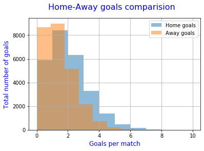

```python
home = df2.home_team_goal
away = df2.away_team_goal

home.hist(alpha=0.5, label='Home goals')
away.hist(alpha=0.5, label='Away goals')
def set_labeles(title, x, y):
    suptitle(title, size=16, color='b')
    xlabel(x, size=12, color='b')
    ylabel(y, size=12, color='b')
set_labeles('Home-Away goals comparision', 'Goals per match', 'Total number of goals')
plt.legend()
```

The X-axis indicate the number of goals in a match. And the Y-axis tells us how many matches ended with that many goals.  
We can see that the home team does not blank as much as the away team. It is also more likely for a home team to score over 2 goals in one match.

Now let us see it in a bar chart.

```
<BarContainer object of 2 artists>
```

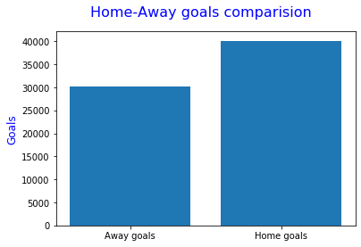

```python
home = home.sum()
away = away.sum()

names = ['Away goals', 'Home goals']
values = [away, home]
set_labeles('Home-Away goals comparision', '', 'Goals')

plt.bar(names, values)
```

The X-axis is seperated as Home goals and Away goals. The Y-axis indicates the total number of goals.

The chart clearly shows that home goals are more than away goals, which increases the chance of winning.

## 3- What is the relation between the preferred foot and the overall rating for players?

## Data Wrangling

### General Properties

```python
df3 = pd.read_csv('Player_Attributes.csv')
df3.info()
```

```
<class 'pandas.core.frame.DataFrame'>
RangeIndex: 183978 entries, 0 to 183977
Data columns (total 42 columns):
 #   Column               Non-Null Count   Dtype
---  ------               --------------   -----
 0   id                   183978 non-null  int64
 1   player_fifa_api_id   183978 non-null  int64
 2   player_api_id        183978 non-null  int64
 3   date                 183978 non-null  object
 4   overall_rating       183142 non-null  float64
 5   potential            183142 non-null  float64
 6   preferred_foot       183142 non-null  object
 7   attacking_work_rate  180748 non-null  object
 8   defensive_work_rate  183142 non-null  object
 9   crossing             183142 non-null  float64
```

[output cut: 34 more lines]

Notice that there are some missing values in "preferred_foot" column, but that should not be a problem.

### Data Cleaning steps

```
-Drop Unneccessery columns.
-Drop duplicate players. The table should be sorted by date so we only keep the latest update of the player's
rating, and so we don't have a problem with missing "preferred_foot" values.
```

```python
df3.sort_values(by=['date'], ascending=False, inplace=True)
df3.drop_duplicates(subset='player_api_id', inplace=True)
cols_to_keep = ['overall_rating', 'preferred_foot']
df3 = df3[cols_to_keep]
```

## Exploratory Data Analysis

```python
y1 = sort(df3[df3.preferred_foot == 'right'].overall_rating)
y2 = sort(df3[df3.preferred_foot == 'left'].overall_rating)

uniqueR, countsR = np.unique(y1, return_counts=True)
uniqueL, countsL = np.unique(y2, return_counts=True)

rangex = list(set(uniqueR) | set(uniqueL))
rangex = [int(i) for i in rangex]

all_ratings = [i for i in range(40, 100)]
allR = []
allL = []
x = y = 0

for i in all_ratings:
    if i in uniqueR:
        allR.append(countsR[x])
        x += 1
    else:
        allR.append(0)
    if i in uniqueL:
        allL.append(countsL[y])
        y += 1
    else:
        allL.append(0)
        r, l, labels, foot = ([] for i in range(4))
x, cr, cl = (0 for i in range(3))
temp = [20, 10, 10, 20]
labels = ['over 40', 'over 60', 'over 70', 'over 80']

for i in range(60):
    cr += allR[i]
    cl += allL[i]
    if (i+1) % temp[x] == 0:
        r.append(cr)
        l.append(cl)
        foot.append('left')
        foot.append('right')
        cr = cl = 0
        x += 1

def percentage(in_list):
    out_list = [int((i/sum(in_list))*100) for i in in_list]
    return out_list

leftp = percentage(l)
rightp = percentage(r)

bothp = leftp + rightp
rates = labels + labels
foot.sort()

leftdata = {'left percentage': leftp, 'foot': 'Left foot', 'labels': labels}
rightdata = {'right percentage': rightp, 'foot': 'Right foot', 'labels': labels}
bothdata = {'rates': rates, 'ratings': bothp, 'foot': foot}

left_table = pd.DataFrame (leftdata, columns = ['left percentage', 'foot', 'labels'])
right_table = pd.DataFrame (rightdata, columns = ['right percentage', 'foot', 'labels'])
bothtable = pd.DataFrame (bothdata, columns = ['rates', 'ratings', 'foot'])

leftfig = px.sunburst(left_table, path=['foot', 'labels'], values='left percentage')
rightfig = px.sunburst(right_table, path=['foot', 'labels'], values='right percentage')
bothfig = px.sunburst(bothtable, path=['rates', 'foot'], values='ratings')
```

The cells above calculates the percentage of players with right and left preferred foot, then add it to a dataframe to be visualized.

```python
leftfig.show()
rightfig.show()
```

[interactive chart not shown]

The charts above show the distirebution of players of a specific preferred foot over the overall_rating classes.  
The first layer is the title of this chart. The second layer shows the rating classes percentage.

The next chart compairs the distirebution of left and right footed players over the overall_rating classes.

```python
bothfig.show()
```

[interactive chart not shown]

The rating classes percentage is shown in the first layer. The second layer indicates the preferred foot.

From this chart, we can see that the preferred foot does not have a big impact on the overall_rating of a player. The differences in the distirebution are only 1%.

## 4- Which team improved the most at shooting?

## Data Wrangling

### General Properties

```python
shootdf = pd.read_csv('Team_Attributes.csv')
shootdf.info()
```

```
<class 'pandas.core.frame.DataFrame'>
RangeIndex: 1458 entries, 0 to 1457
Data columns (total 25 columns):
 #   Column                          Non-Null Count  Dtype
---  ------                          --------------  -----
 0   id                              1458 non-null   int64
 1   team_fifa_api_id                1458 non-null   int64
 2   team_api_id                     1458 non-null   int64
 3   date                            1458 non-null   object
 4   buildUpPlaySpeed                1458 non-null   int64
 5   buildUpPlaySpeedClass           1458 non-null   object
 6   buildUpPlayDribbling            489 non-null    float64
 7   buildUpPlayDribblingClass       1458 non-null   object
 8   buildUpPlayPassing              1458 non-null   int64
 9   buildUpPlayPassingClass         1458 non-null   object
```

[output cut: 17 more lines]

After reading data, we check if there are missing tuples in the columns that we need, luckly there isn't any.

### Data Cleaning steps

```
-Drop Unneccessery columns.
-sort data by "date".
```

```python
shootdf.sort_values(by=['date'], inplace=True)
cols_to_keep = ['team_api_id', 'chanceCreationShooting']
shootdf = shootdf[cols_to_keep]
```

## Exploratory Data Analysis

To answer the question, we need to find the difference between the last and first "chanceCreationShooting" for each team.

```python
first1 = last1 = shootdf
first = first1.drop_duplicates(subset='team_api_id', keep='first')
last = last1.drop_duplicates(subset='team_api_id', keep='last')

first = first.sort_values(by='team_api_id')
last = last.sort_values(by='team_api_id')

last_update = last['chanceCreationShooting']
first_update = first['chanceCreationShooting']

improvement = list(np.array(last_update) - np.array(first_update))

last['first_update'] = list(first_update)
last['improvement'] = improvement
last.rename(columns={'chanceCreationShooting': 'last_update'}, inplace=True)
last = last[last['improvement'] == max(last['improvement'])]
last
```

|  | team_api_id | last_update | first_update | improvement |
| --- | --- | --- | --- | --- |
| 878 | 8481 | 67 | 30 | 37 |

We found the team's id, last and first skill update and the team's improvement. Now lets find the team name by merging this table with "Team" table and match "team_api_id"

```python
teamdf = pd.read_csv('Team.csv')
cols_to_keep = ['team_api_id', 'team_long_name']
teamdf = teamdf[cols_to_keep]
newdf = pd.merge(right=teamdf, left=last)
cols_to_keep = ['team_long_name', 'last_update', 'first_update', 'improvement']
newdf = newdf[cols_to_keep]
newdf
```

|  | team_long_name | last_update | first_update | improvement |
| --- | --- | --- | --- | --- |
| 0 | AS Nancy-Lorraine | 67 | 30 | 37 |

AS Nancy-Lorraine has improved the most at shooting

## Conclusions

In this project, we asked four questions regarding the dataset, then used some Python libraries to find answers.  
The first question was about finding the fastest player, not only his sprinting speed but the total speed of a player. We found out that Mathis Bolly is the fastest player with a total speed of 194.  
Seconly, we asked about the effect of playing at home to the result of the match, the result was that playing at home does effect the result of the match positively.  
Then we asked about the relation between the preferred foot and the overall rating of a player. It was quite interesting because I always thaught that left foot players were better, but the result showed that the preferred foot does not have a relation with the overall rating.  
Finally, we looked for the team that improved the most at shooting, we applied similar steps as the first question, and found that AS Nancy-Lorraine has improved the most over the years with 37 points of improvement. Started with 30 points then finally became 67.

### Limitations

There have been some limitations regarding this analysis. Firstly, the database had some important missing values. for example, the possession of the ball in the match is completely missing. Also, my skills in data analysis are basic and mostly comes from simple query-based analysis.